# Multiple Imputation in complex settings

The focus of this practical is the imputation of data that has features that require special attention. In the interest of time, we will focus on these features and abbreviate steps that are the same as in any imputation setting (e.g., getting to know the data or checking that imputed values are realistic). Nevertheless, these steps are of course required when analysing data in practice.

## Non-linear associations

### Data & Model of interest

To practice imputation when non-linear functional forms or interaction terms are involved, we use a subset of the **NHANES** data.

To get the **NHANES** data, load the file `NHANES_2.RData`.

The variables in this subset have the following distributions and proportions of missing values:

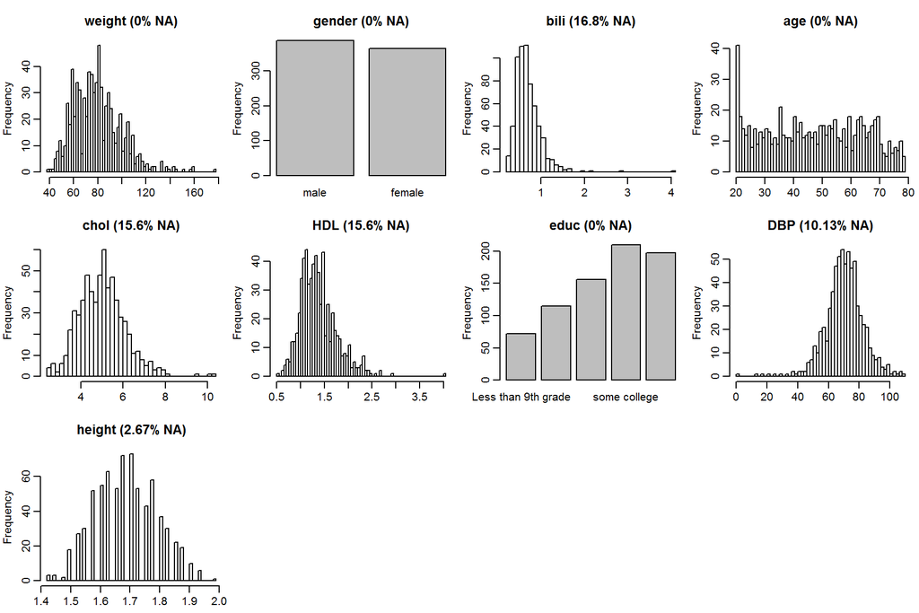

The **missing data pattern** is

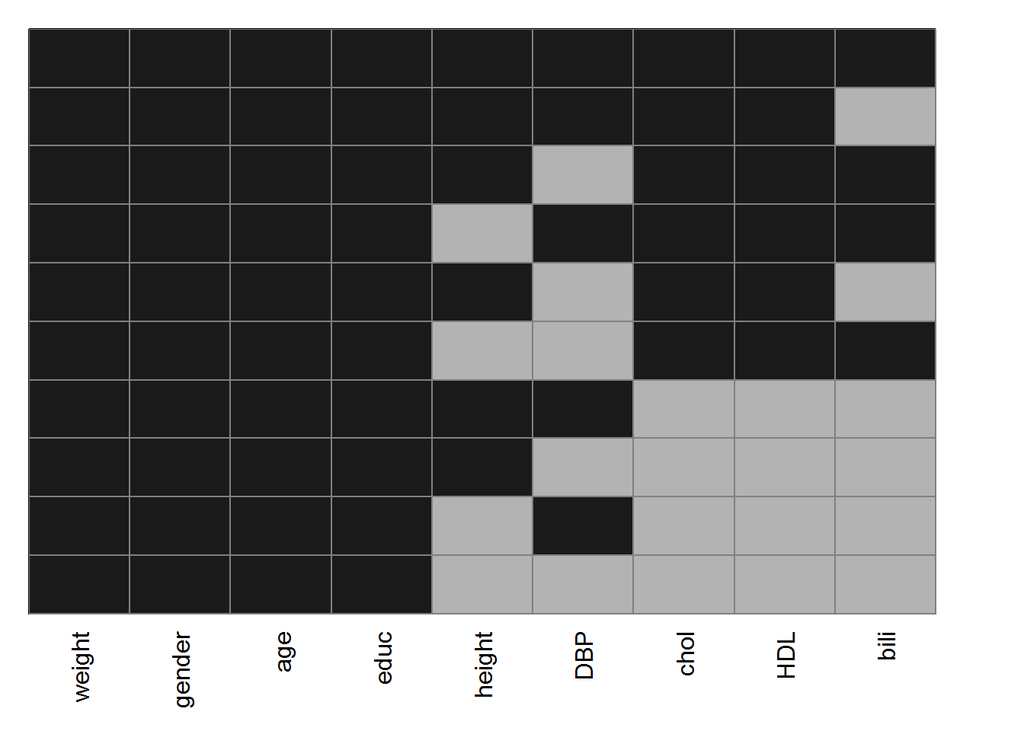

```
##     weight gender age educ height DBP chol HDL bili
## 547      1      1   1    1      1   1    1   1    1   0
##   8      1      1   1    1      1   1    1   1    0   1
##  59      1      1   1    1      1   0    1   1    1   1
##  13      1      1   1    1      0   1    1   1    1   1
##   1      1      1   1    1      1   0    1   1    0   2
##   5      1      1   1    1      0   0    1   1    1   2
## 105      1      1   1    1      1   1    0   0    0   3
##  10      1      1   1    1      1   0    0   0    0   4
##   1      1      1   1    1      0   1    0   0    0   4
##   1      1      1   1    1      0   0    0   0    0   5
##          0      0   0    0     20  76  117 117  126 456
```

Our aim is to fit the following **linear regression model for weight**:

```r
mod <- lm(weight ~ gender + bili + age * (chol + HDL) + height)
```

We expect that the effects of cholesterol and HDL may differ with age, and, hence, include **interaction terms** between `age` and `chol` and `HDL`, respectively. Additionally, we want to include `educ` and `DBP` as auxiliary variables.

### Imputation using **mice**

When the analysis model of interest involves interaction terms between incomplete variables, **mice** has limited options to reduce the bias that may be introduced by naive handling of the missing values.

Use of the “Just Another Variable” approach can in some settings reduce bias. Alternatively, we can use passive imputation, i.e., calculate the interaction terms in each iteration of the MICE algorithm. Furthermore, predictive mean matching tends to lead to less bias than normal imputation models.

#### Task 1

Calculate the interaction terms in the incomplete data and perform the imputation with `mice()`, using the **JAV approach and using passive imputation**. Follow the usual procedure of doing a setup run and adjusting the imputation method and predictor matrix.

#### Solution 1

```r
# calculate the interaction terms
NHANES$agechol <- NHANES$age * NHANES$chol
NHANES$ageHDL <- NHANES$age * NHANES$HDL

# setup run
miceint0 <- mice(NHANES, maxit = 0)

meth_miceint <- miceint0$method
pred_miceint <- miceint0$predictorMatrix

# change the imputation method:
meth_miceint["DBP"] <- "norm"
# replace all "pmm" with "midastouch"
meth_miceint <- gsub("pmm", "midastouch", meth_miceint)

# changes in predictor matrix to prevent that the original variables are
# imputed based on the interaction terms
pred_miceint["chol", "agechol"] <- 0
pred_miceint["HDL", "ageHDL"] <- 0

# changes in imputation method for passive imputation only
meth_miceintPAS <- meth_miceint
meth_miceintPAS[c("agechol", "ageHDL")] <- c("~I(age*chol)", "~I(age*HDL)")

# run imputation with the JAV approach
miceintJAV <- mice(NHANES, method = meth_miceint, predictorMatrix = pred_miceint,
                maxit = 10, m = 5)
# run imputation with passive imputation
miceintPAS <- mice(NHANES, method = meth_miceintPAS, predictorMatrix = pred_miceint,
                maxit = 10, m = 5)
```

#### Task 2

We skip the evaluation of convergence and investigation of the imputed values. With the settings given in the solution the chains have converged and distributions of the imputed values match the distributions of the observed data close enough. Omitting the changes in the `predictorMatrix` would have resulted in convergence problems for `HDL`, `ageHDL`, `chol` and `agechol`.

Analyse the imputed data and pool the results.

#### Solution 2

```r
miceint_miraJAV <- with(miceintJAV,
                     lm(weight  ~ gender + bili + age + chol + HDL + agechol +
                          ageHDL + height))

miceint_miraPAS <- with(miceintPAS,
                     lm(weight  ~ gender + bili + age + chol + HDL + agechol +
                          ageHDL + height))

summary(pool(miceint_miraJAV))
```

```
##                      est          se          t        df     Pr(>|t|)
## (Intercept) -77.18703933 16.70269165 -4.6212336 143.12052 8.435536e-06
## gender2       4.43604424  1.63880389  2.7068792 676.46058 6.963279e-03
## bili         -6.39589823  2.14575439 -2.9807224  91.34665 3.685076e-03
## age           0.19363251  0.19528034  0.9915617  12.63208 3.400256e-01
## chol          3.95412999  2.18229289  1.8119154  10.15331 9.963588e-02
## HDL         -25.90904259  5.60542781 -4.6221347  44.14898 3.302939e-05
## agechol      -0.08348875  0.04042668 -2.0651891  11.50275 6.219948e-02
## ageHDL        0.26022290  0.10826998  2.4034630  41.54839 2.078417e-02
## height      100.23789969  7.72687103 12.9726379 458.48946 0.000000e+00
##                     lo 95         hi 95 nmis        fmi     lambda
## (Intercept) -110.20288235 -44.171196307   NA 0.15865577 0.14698020
## gender2        1.21829041   7.653798071   NA 0.02266526 0.01977998
## bili         -10.65795782  -2.133838638  126 0.20969237 0.19257626
## age           -0.22949750   0.616762529    0 0.60921651 0.55188358
## chol          -0.89838766   8.806647638  117 0.67466134 0.61632197
## HDL          -37.20496340 -14.613121767  117 0.31829396 0.28809589
## agechol       -0.17199509   0.005017596  117 0.63680057 0.57870145
## ageHDL         0.04165485   0.478790957  117 0.32913672 0.29760259
## height        85.05342719 115.422372184   20 0.05885143 0.05475493
```

```r
summary(pool(miceint_miraPAS))
```

```
##                      est          se         t        df     Pr(>|t|)
## (Intercept) -87.08484063 17.29836485 -5.034282 451.76109 6.940959e-07
## gender2       4.99260042  1.67250699  2.985100 446.09401 2.990716e-03
## bili         -5.72815097  2.21353918 -2.587779  55.51622 1.230510e-02
## age           0.31375316  0.19883812  1.577933 152.37901 1.166548e-01
## chol          4.23474865  2.03179080  2.084244  77.26636 4.044269e-02
## HDL         -23.14504686  5.28887693 -4.376174 151.79804 2.235895e-05
## agechol      -0.08372924  0.04008505 -2.088790  59.60643 4.100558e-02
## ageHDL        0.18071643  0.09916424  1.822395 175.59610 7.009616e-02
## height      102.38469325  7.59235298 13.485239 572.08756 0.000000e+00
##                     lo 95         hi 95 nmis        fmi     lambda
## (Intercept) -121.08008898 -53.089592275   NA 0.06002067 0.05586847
## gender2        1.70562899   8.279571840   NA 0.06101597 0.05681559
## bili         -10.16325566  -1.293046284  126 0.28001795 0.25453917
## age           -0.07908226   0.706588574    0 0.15228938 0.14123558
## chol           0.18915885   8.280338446  117 0.23153571 0.21189856
## HDL          -33.59436046 -12.695733268  117 0.15267264 0.14158182
## agechol       -0.16392217  -0.003536308  117 0.26894981 0.24482530
## ageHDL        -0.01499073   0.376423585  117 0.13847101 0.12871396
## height        87.47240612 117.296980370   20 0.04037791 0.03702896
```

Because we want to perform the imputation with other methods on the same original dataset, we remove the two columns `agechol` and `ageHDL` that we had added to the data.

```r
NHANES <- subset(NHANES, select = -c(agechol, ageHDL))
```

### Imputation using **JointAI**

The package **JointAI** performs analysis and imputation jointly. There are three main functions, `lm_imp()`, `glm_imp()` and `lme_imp()` that perform linear regression, generalized linear regression and analysis with linear mixed models. The specification of these functions is very similar to the use of their complete data versions `lm()`, `glm()` and `lme` (from the **nlme** package).

#### Task 1

Check the [help file](https://www.rdocumentation.org/packages/JointAI/versions/0.1.0/topics/model_imp) for `lm_imp()` to find out which arguments you need to specify to fit the linear regression model for `weight`.

#### Solution 1

`lm_imp()`, `glm_imp()` and `lme_imp()` have many arguments, but not all of them are relevant for this practical. The most important arguments are:

[output not shown]

**Additional details:**  
Contrary to MICE, the `n.chains` different MCMC chains are not used to create multiple imputed datasets. Multiple chains are necessary to evaluate if the model has converged. For the final result the chains are combined.

Depending on the type of variable, different types of samplers (within the Gibbs sampling) are used. JAGS (which is called from within `lm_imp()`) needs an adaptive phase to find a suitable sampler for each of the parameters. Often `n.adapt = 100` iterations (the default value) are sufficient for the adaption phase. These iterations are not included in the final result.

The number of iterations `n.iter` that is required depends on the specific data and how complex the model is, hence, no default value is given.

Columns of the dataset that are not used in the model formula, and are not specified as auxiliary variables are ignored. In the current version of **JointAI**, passive imputation (calculating variables based on other variables) is not yet available.

#### Task 2

Analyse (and impute) the data using `lm_imp()` and the linear regression model specified above.

- Start with a small number of iterations, say `n.iter = 100`, to get an idea about the computational time.
- Check convergence of the MCMC chains using `traceplot()`.
- Increase `n.iter` if necessary.

You need to specify the

- model formula
- the dataset
- auxiliary variables
- the number of iterations for the sample
- set `inits = NULL`

`traceplot()` shows by default the MCMC chains of the main model parameters. This is different to the traceplots we have seen when using `mice()`, but the principle of convergence is the same.

**Note:**  
Due to a bug in version 0.1.0 of **JointAI** you need to specify `inits = NULL` when using auxiliary variables. This bug is resolved in the development version on GitHub.

#### Solution 2

```r
library(JointAI)
JointAIint <- lm_imp(weight ~ gender + bili + age * (chol + HDL) + height,
                  data = NHANES,
                  auxvars = c("educ", "DBP"),
                  n.iter = 500, inits = NULL)
```

```
## This is new software. Please report any bug to the package maintainer.
```

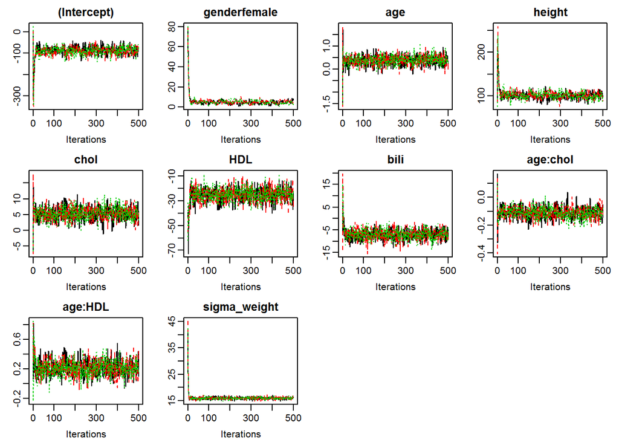

```r
traceplot(JointAIint)
```

```r
summary(JointAIint, start = 200)
```

```
##
##  Linear model fitted with JointAI
##
## Call:
## lm_imp(formula = weight ~ gender + bili + age * (chol + HDL) +
##     height, data = NHANES, n.iter = 500, inits = NULL, auxvars = c("educ",
##     "DBP"))
##
## Posterior summary:
##                  Mean       SD       2.5%     97.5% tail-prob.
## (Intercept)  -87.4065 17.70350 -120.71547 -54.11272   0.000000
## genderfemale   4.7690  1.62039    1.66363   8.13141   0.000000
## age            0.3981  0.19853    0.02527   0.77211   0.031008
## height       101.1514  7.32407   86.73519 115.24113   0.000000
## chol           5.4071  1.94227    1.71726   9.35201   0.006645
## HDL          -24.5813  5.29108  -34.94515 -13.89334   0.000000
## bili          -7.1244  2.15194  -11.38647  -2.92603   0.000000
## age:chol      -0.1100  0.03892   -0.18684  -0.03479   0.011074
## age:HDL        0.2111  0.10172    0.01793   0.41134   0.028793
##
## Posterior summary of residual std. deviation:
##               Mean     SD  2.5% 97.5%
## sigma_weight 15.97 0.4132 15.16 16.79
##
##
## MCMC settings:
## Iterations = 200:500
## Sample size per chain = 301
## Thinning interval = 1
## Number of chains = 3
##
## Number of observations: 750
```

### Imputation using **smcfcs**

The package **smcfcs** performs imputation using “substantive model compatible fully conditional specification”.

The main function is called `smcfcs()` and its use is similar to the use of `mice()`.

#### Task 1

Check the [help file](https://www.rdocumentation.org/packages/smcfcs/versions/1.3.0/topics/smcfcs) to find out the details of this function.

#### Solution 1

`smcfcs()` takes the following arguments as input:

[output not shown]

**Additional details:**

The vector of imputation methods needs to be specified in the order of the columns in the dataset and contain an entry for each column, even that column is not used in the imputation model. Depending on whether additional columns of the data should be used as auxiliary variables in the imputation, the `predictorMatrix` needs to be adjusted (0 if the column should not be used, 1 if it should be used).

In `smcfcs()` the outcome of the analysis model is implicitely included in the imputation model, similarily to how it is included in **JointAI**. Therefore, the outcome does not need to be explicitely specified as predictor variable for the imputation models in the `predictorMatrix`.

**smcfcs** uses *rejection sampling*. Rejection sampling is a method to create a random sample from a complex distribution (from which we can not sample directly) by drawing from a simpler proposal distribution and rejecting draws that are unlikely under the complex target distribution. The argument `rjlimit` specifies how many attepts are made to draw a value from the proposal that is not rejected.

For logistic regression, `smcfcs` requires the outcome to be coded as numeric (with values 0 and 1).

#### Task 2

Impute the NHANES data with `smcfcs()` and take into account that `DBP` and `educ` should be used as auxiliary variables.  
=> you need to specify the `predictorMatrix` to specify this

To create the predictor matrix: `pred <- matrix(nrow = ncol(NHANES), ncol = ncol(NHANES), data = 1, dimnames = list(names(NHANES), names(NHANES)))`

Then exclude variables from their own imputation model: `diag(pred) <- 0`

In `smcfcs()` you need to specify

- the data
- the model type
- the model formula
- the vector of imputation methods
- the predictor matrix
- possibly the number of iterations

#### Solution 2

```r
# To create the predictor matrix:
pred <- matrix(nrow = ncol(NHANES), ncol = ncol(NHANES), data = 1,
               dimnames = list(names(NHANES), names(NHANES)))
# exclude variables from their own imputation model
diag(pred) <- 0


smcint <- smcfcs(NHANES,
                 smtype = "lm",
                 smformula = "weight ~ gender + bili + age * (chol + HDL) + height",
                 method = c(weight = "", gender = "", bili = "norm", age = "",
                            chol = "norm", HDL = "norm", educ = "", DBP = 'norm',
                            height = 'norm'),
                 predictorMatrix = pred, numit = 20)
```

```
## [1] "Outcome variable(s): weight"
## [1] "Passive variables: "
## [1] "Partially obs. variables: bili,chol,HDL,DBP,height"
## [1] "Fully obs. substantive model variables: gender,age"
## [1] "Imputation  1"
## [1] "Imputing:  bili  using  gender,age,chol,HDL,educ,DBP,height  plus outcome"
## [1] "Imputing:  chol  using  gender,bili,age,HDL,educ,DBP,height  plus outcome"
## [1] "Imputing:  HDL  using  gender,bili,age,chol,educ,DBP,height  plus outcome"
## [1] "Imputing:  DBP  using  gender,bili,age,chol,HDL,educ,height  plus outcome"
## [1] "Imputing:  height  using  gender,bili,age,chol,HDL,educ,DBP  plus outcome"
## [1] "Imputation  2"
## [1] "Imputation  3"
## [1] "Imputation  4"
## [1] "Imputation  5"
```

#### Task 3

Find out the `class` of the object returned by `smcfcs()` and its elements. The section **Value** in the [help page](https://www.rdocumentation.org/packages/smcfcs/versions/1.3.0/topics/smcfcs) can help with this.

The estimates of the model parameters from each iteration are returned in the list element `smCoefIter`.

Then plot the chains of the estimated model parameters to evaluate if the algorithm has converged.

#### Solution 3

```r
# class of the returned object
class(smcint)
```

```
## [1] "list"
```

```r
# names of its components
names(smcint)
```

```
## [1] "impDatasets" "smCoefIter"
```

```r
# investigate the first component
class(smcint$impDatasets)
```

```
## [1] "list"
```

```r
length(smcint$impDatasets)
```

```
## [1] 5
```

```r
class(smcint$impDatasets[[1]])
```

```
## [1] "data.frame"
```

```r
dim(smcint$impDatasets[[1]])
```

```
## [1] 750   9
```

```r
# investigate the second component
class(smcint$smCoefIter)
```

```
## [1] "array"
```

```r
dim(smcint$smCoefIter)
```

```
## [1]  5  9 20
```

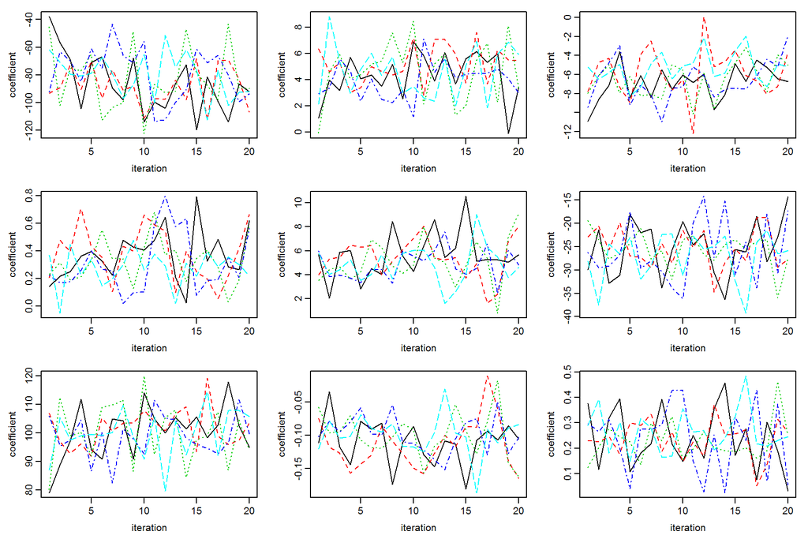

```r
# plot the chains of estimated coefficients
par(mfrow = c(3, 3), mar = c(3.5, 3.5, 1,1), mgp = c(2, 0.6, 0))
for (i in 1:dim(smcint$smCoefIter)[2]) {
  matplot(t(smcint$smCoefIter[, i, ]), type = 'l', ylab = "coefficient",
          xlab = "iteration")
}
```

#### Continue

The imputed datasets are returned as a `list`, where each element of the `list` is one imputed dataset.

To get from a `list` of datasets to pooled results there are several options, as displayed in the following flow chart:

[figure not shown]

To use `datalist2mids()` from the package **miceadds**, ordered factors need to be converted to unordered factors. To use `as.mids()` we would have to turn the list into a long format dataset (where the original data and all imputed datasets are stacked on top of each other) and add a column that identifies the imputation number and one that identifies subjects.

#### Task 4

Instead do the following:

1. convert `smcint` to an `imputationList` object
2. fit the models on this `imputationList` object
3. use `MIcombine()` to obtain an `MIresult` object
4. use `as.mira()` to convert the `list` of models from 2. to a `mira` object
5. use `pool()` on the `mira` object
6. compare the `summary()` of the `mira` object and the `summary()` of the `MIresult` object

#### Solution 4

```r
# 1. convert to imputationList
library(mitools)
smcint_impList <- imputationList(smcint$impDatasets)

# 2. fit the models
intmod_mitools <- with(smcint_impList,
                       lm(weight ~ gender + bili + age * (chol + HDL) + height))

# 3. Pool the results
smcintpool_mitools <- MIcombine(intmod_mitools)

# 4. create a mira object
smcint_mira <- as.mira(intmod_mitools)


# 5. pool the mira object
smcintpool_mice <- pool(smcint_mira)

# 6. compare the results
summary(smcintpool_mitools)
```

```
## Multiple imputation results:
##       with(smcint_impList, lm(weight ~ gender + bili + age * (chol +
##     HDL) + height))
##       MIcombine.default(intmod_mitools)
##                  results          se        (lower       upper) missInfo
## (Intercept)  -88.3886173 17.39779948 -122.57105315 -54.20618154      9 %
## genderfemale   4.9908978  1.66443312    1.72612065   8.25567490      5 %
## bili          -6.0023868  2.12371006  -10.20522667  -1.79954688     19 %
## age            0.4055262  0.19228242    0.02661936   0.78443313     14 %
## chol           5.3913079  1.99967215    1.41099052   9.37162529     24 %
## HDL          -24.6280024  5.05750575  -34.56407046 -14.69193424      9 %
## height       101.1642673  7.54699065   86.36539781 115.96313675      4 %
## age:chol      -0.1100166  0.04145684   -0.19399623  -0.02603695     36 %
## age:HDL        0.2094764  0.09893174    0.01449382   0.40445895     14 %
```

```r
summary(smcintpool_mice)
```

```
##                      est          se         t        df     Pr(>|t|)
## (Intercept)  -88.3886173 17.39779948 -5.080448 285.55674 6.812755e-07
## genderfemale   4.9908978  1.66443312  2.998557 482.99339 2.852527e-03
## bili          -6.0023868  2.12371006 -2.826368 104.17754 5.645016e-03
## age            0.4055262  0.19228242  2.109014 166.37063 3.644039e-02
## chol           5.3913079  1.99967215  2.696096  69.35393 8.797646e-03
## HDL          -24.6280024  5.05750575 -4.869595 290.53703 1.839345e-06
## height       101.1642673  7.54699065 13.404584 554.92516 0.000000e+00
## age:chol      -0.1100166  0.04145684 -2.653762  34.66209 1.193270e-02
## age:HDL        0.2094764  0.09893174  2.117383 162.83296 3.574619e-02
##                      lo 95       hi 95 nmis        fmi     lambda
## (Intercept)  -122.63281460 -54.1444201   NA 0.09609269 0.08978395
## genderfemale    1.72047360   8.2613220   NA 0.05469426 0.05078798
## bili          -10.21369906  -1.7910745   NA 0.19368174 0.17834923
## age             0.02589817   0.7851543   NA 0.14363782 0.13340470
## chol            1.40243428   9.3801815   NA 0.24656243 0.22514394
## HDL           -34.58199628 -14.6740084   NA 0.09469513 0.08848456
## height         86.34010519 115.9884294   NA 0.04309168 0.03964910
## age:chol       -0.19420778  -0.0258254   NA 0.36334717 0.32764243
## age:HDL         0.01412183   0.4048309   NA 0.14572635 0.13529776
```

### Imputation using **jomo**

In this part of the practical we will use **jomo** to impute the NHANES data with the joint model approach to multiple imputation. For our linear regression of `weight`, this can be done using the function `jomo.lm()`.

#### Task 1

Check the [help page](https://www.rdocumentation.org/packages/jomo/versions/2.6-1/topics/jomo.lm) to find out which arguments need to be specified in `jomo.lm()`.

#### Solution 1

The main arguments of `jomo.lm()` are:

[output not shown]

**Additional details:**

**jomo** only produces a single chain of MCMC samples. The first `nburn` iterations are discarded as burn-in. The next iteration forms the first imputed dataset. The MCMC chain is then continued and after `nbetween` additional iterations the next imputed dataset is created. This step is repeated until `nimp` sets of imputed values are obtained.

Convergence of the MCMC sampler can not be checked on the same object that was used to create the imputed values. Instead, a separate function has to be used: `jomo.lm.MCMCchain()`. It takes the same arguments as `jomo.lm()`, except for `nbetween` and `nimp`, and records all burn-in iterations, but does not create multiple imputed datasets.

**jomo** will use all columns that are in the dataset but not used in the model formula as auxiliary variables. As in **JointAI**, specification of passive imputation is currently not available.

#### Task 2

Run `jomo.lm.MCMCchain()` for our linear regression of `weight` and investigate the resulting object.

You need to specify

- the model formula
- the dataset
- the distribution family of the outcome
- the number of burn-in iterations

#### Solution 2

```r
jomointMCMC <- jomo.lm.MCMCchain(weight ~ gender + bili + age * (chol + HDL) + height,
                    data = NHANES, output = 0)
```

```
## This function is beta software. Use carefully and please report any bug to the package mantainer
```

```r
class(jomointMCMC)
```

```
## [1] "list"
```

```r
names(jomointMCMC)
```

```
## [1] "finimp"         "collectbeta"    "collectomega"   "finimp.latnorm"
## [5] "collectbetaY"   "collectvarY"
```

```r
lapply(jomointMCMC, class)
```

```
## $finimp
## [1] "data.frame"
##
## $collectbeta
## [1] "array"
##
## $collectomega
## [1] "array"
##
## $finimp.latnorm
## [1] "matrix"
##
## $collectbetaY
## [1] "array"
##
## $collectvarY
## [1] "numeric"
```

`jomoint` is a `list` with six elements:

- `finimp` is the imputed dataset that was generated at the end of the burn-in period
- `finimp.latnorm` contains a `matrix` corresponding estimates of the latent normal distributions
- `collectbetaY` and `collectvarY` contain the MCMC samples throughout the burn-in period for the coefficients of the analysis model and residual variation
- `collectbeta` and `collectomega` contain the MCMC samples throughout the burn-in period for the mean and variance-covariance matrix of the multivariate normal distribution.

#### Task 3

Make plots to evaluate convergence.

#### Solution 3

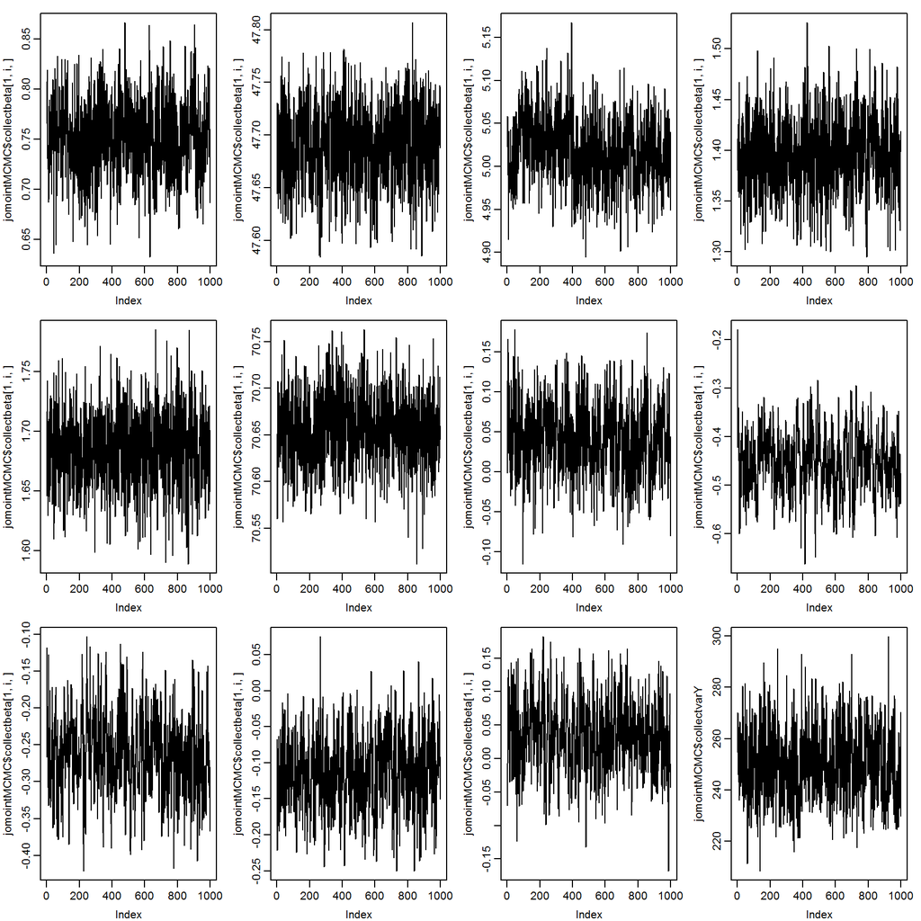

```r
par(mfrow = c(3,4), mar = c(3,3,1,1), mgp = c(2, 0.6, 0))
for (i in 1:dim(jomointMCMC$collectbeta)[2]) {
  plot(jomointMCMC$collectbeta[1, i, ], type = 'l')
}

plot(jomointMCMC$collectvarY, type = 'l')
```

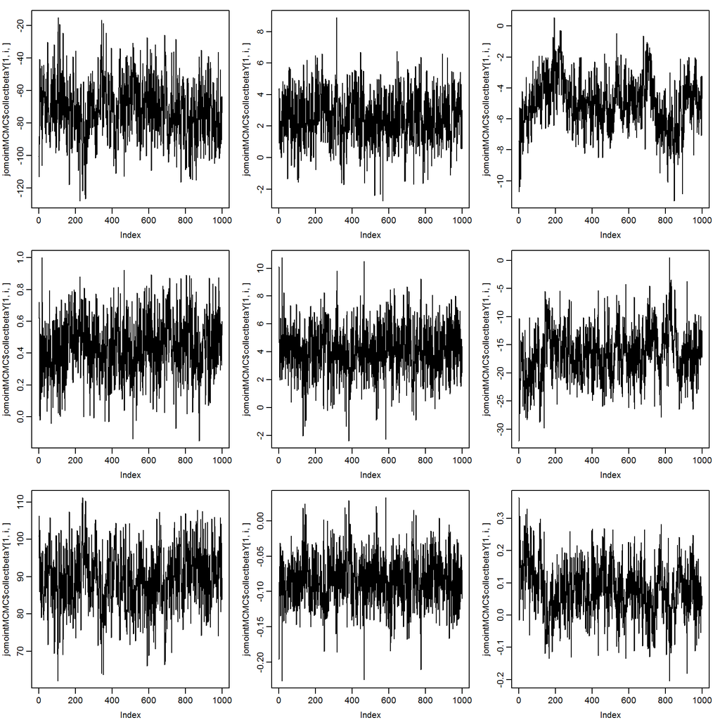

```r
par(mfrow = c(3,3), mar = c(3,3,1,1), mgp = c(2, 0.6, 0))
for (i in 1:dim(jomointMCMC$collectbetaY)[2]) {
  plot(jomointMCMC$collectbetaY[1, i, ], type = 'l')
}
```

[figure not shown]

```r
par(mfrow = c(11, 11), mar = c(3,3,1,1), mgp = c(2, 0.6, 0))
for (i in 1:dim(jomointMCMC$collectomega)[2]) {
  for (j in 1:i) {
    plot(jomointMCMC$collectomega[i, j , ], type = 'l')
  }
}
```

#### Task 4

When you are satisfied with the convergence, run the imputation with the number of burn-in iterations that you found to be sufficient and explore the resulting object.

#### Solution 4

```r
jomoint <- jomo.lm(weight ~ gender + bili + age * (chol + HDL) + height,
                    nburn = 1000, nbetween = 200, nimp = 5, data = NHANES)
```

[output not shown]

```r
class(jomoint)
```

```
## [1] "data.frame"
```

```r
dim(jomoint)
```

```
## [1] 4500   11
```

```r
summary(jomoint)
```

```
##      weight            bili              age             chol
##  Min.   : 38.56   Min.   :-2.3844   Min.   :20.00   Min.   : 1.552
##  1st Qu.: 64.86   1st Qu.: 0.5000   1st Qu.:33.00   1st Qu.: 4.240
##  Median : 78.02   Median : 0.7000   Median :48.00   Median : 4.990
##  Mean   : 79.74   Mean   : 0.7495   Mean   :47.69   Mean   : 5.016
##  3rd Qu.: 90.72   3rd Qu.: 0.9000   3rd Qu.:63.00   3rd Qu.: 5.643
##  Max.   :176.90   Max.   : 4.1000   Max.   :79.00   Max.   :10.290
##                   NA's   :126                       NA's   :117
##       HDL             height           DBP            gender
##  Min.   :-1.642   Min.   :1.110   Min.   :  0.00   male  :2322
##  1st Qu.: 1.090   1st Qu.:1.600   1st Qu.: 64.67   female:2178
##  Median : 1.340   Median :1.676   Median : 70.67
##  Mean   : 1.389   Mean   :1.685   Mean   : 70.65
##  3rd Qu.: 1.630   3rd Qu.:1.778   3rd Qu.: 76.67
##  Max.   : 4.067   Max.   :2.239   Max.   :110.00
##  NA's   :117      NA's   :20      NA's   :76
##                    educ            id          Imputation
##  Less than 9th grade : 432   Min.   :  1.0   Min.   :0.0
##  9-11th grade        : 690   1st Qu.:188.0   1st Qu.:1.0
##  High school graduate: 936   Median :375.5   Median :2.5
##  some college        :1260   Mean   :375.5   Mean   :2.5
##  College or above    :1182   3rd Qu.:563.0   3rd Qu.:4.0
##                              Max.   :750.0   Max.   :5.0
##
```

#### Task 5

`jomo.lm()` returns a `data.frame` in long format, including the original data. **jomo** has added a column `id` to identify subjects and a column `Imputation` that identifies the imputation number.

With this information and the flowchart from above, fit the linear regression model for `weight` on the imputed data and pool the results.

#### Solution 5

```r
jomoint_mids <- as.mids(jomoint,
                        .imp = which(names(jomoint) == "Imputation"),
                        .id = which(names(jomoint) == "id")
)

jomoint_mira <- with(jomoint_mids,
                     lm(weight ~ gender + bili + age * (chol + HDL) + height))

summary(pool(jomoint_mira))
```

```
##                      est          se         t        df     Pr(>|t|)
## (Intercept) -79.21633923 16.31090176 -4.856650 124.90064 3.500337e-06
## gender2       3.07180164  1.57178011  1.954346 429.03836 5.130954e-02
## bili         -4.54769718  2.00472718 -2.268487  10.91260 4.460607e-02
## age           0.43527436  0.18969414  2.294611  70.40824 2.474059e-02
## chol          4.20651996  1.97763977  2.127041  63.00136 3.733872e-02
## HDL         -16.74859416  4.80479977 -3.485805  23.84551 1.921107e-03
## height       92.90688630  7.02443184 13.226249 291.21829 0.000000e+00
## age:chol     -0.08345604  0.03759351 -2.219959  91.21357 2.889984e-02
## age:HDL       0.08840592  0.09366522  0.943850  19.40017 3.568534e-01
##                     lo 95         hi 95 nmis        fmi     lambda
## (Intercept) -111.49788912 -46.934789332   NA 0.17308055 0.15994448
## gender2       -0.01754572   6.161148993   NA 0.06407484 0.05972209
## bili          -8.96438746  -0.131006900  126 0.65263161 0.59431211
## age            0.05697988   0.813568833    0 0.24441809 0.22325577
## chol           0.25452391   8.158516017  117 0.26057730 0.23747083
## HDL          -26.66861453  -6.828573779  117 0.44324997 0.39843302
## height        79.08179718 106.731975418   20 0.09450624 0.08830886
## age:chol      -0.15812856  -0.008783511   NA 0.20987542 0.19273858
## age:HDL       -0.10736429   0.284176131   NA 0.49295065 0.44324035
```

### Comparison of the results for the NHANES data

We have imputed the NHANES data using five different approaches:

- with **mice**, using the Just Another Variable approach
- with **mice**, using passive imputation of interactions
- with **JontAI**
- with **smcfcs**
- with **jomo**

Here is how the pooled results from these imputations compare:

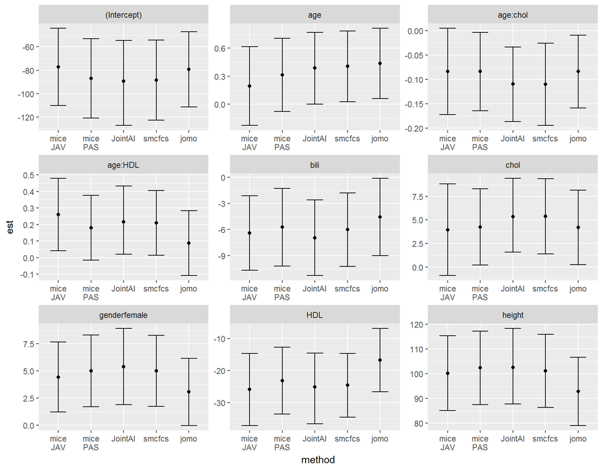

## Longitudinal data

### Data & Model of interest

In this part of the practical, we will work with data on a trial on primary biliary cirrhosis (PBC) of the liver.

To get the **pbclong** data, load the file `pbclong.RData`.

The variables contained in the dataset `pbclong` are:

| `id` | patient identifier |
| --- | --- |
| `protime` | blood clotting time (the longitudinal outcome) |
| `year` | continuously measured year of follow-up time (the time variable) |
| `sex` | patients’ sex (f: female, m: male) |
| `trt` | treatment group (0: D-penicillmain, 1: placebo) |
| `age` | patients’ age at intake |
| `ascites` | presence of ascites at baseline (0:no, 1:yes) |
| `bili` | serum bilirubin level at baseline |
| `chol` | serum cholesterol level at baseline |
| `albumin` | serum albumin level at follow-up (time-varying) |

The variables have the following distributions and proportions of missing values:

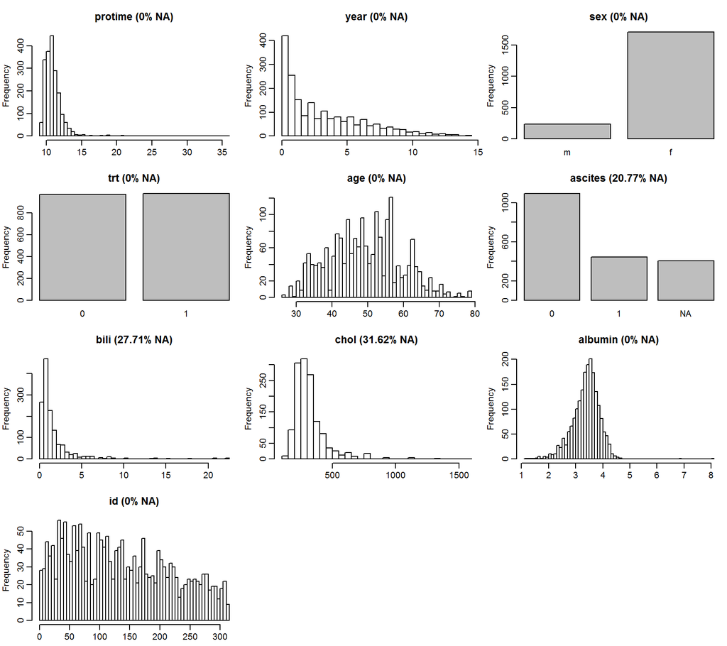

The missing data pattern is:

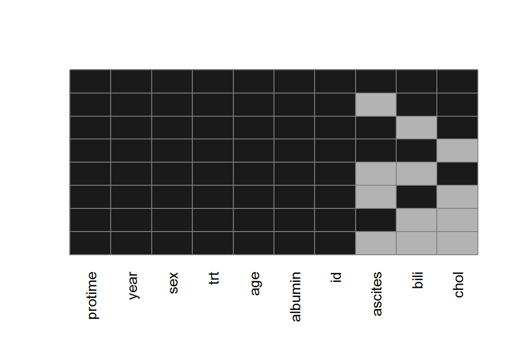

```
##     protime year sex trt age albumin id ascites bili chol
## 839       1    1   1   1   1       1  1       1    1    1    0
## 136       1    1   1   1   1       1  1       0    1    1    1
## 328       1    1   1   1   1       1  1       1    0    1    1
## 245       1    1   1   1   1       1  1       1    1    0    1
##  27       1    1   1   1   1       1  1       0    0    1    2
## 186       1    1   1   1   1       1  1       0    1    0    2
## 129       1    1   1   1   1       1  1       1    0    0    2
##  55       1    1   1   1   1       1  1       0    0    0    3
##           0    0   0   0   0       0  0     404  539  615 1558
```

The longitudinal outcome `protime` shows relatively linear trajectories over time:

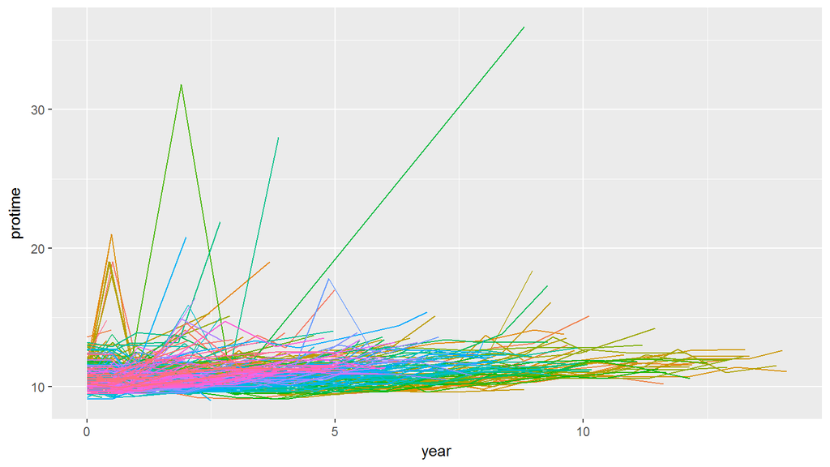

To analyse the trajectories of `protime` we want to use the following linear mixed effects model with random intercept and slope (either using `lme` from the package **nlme** or using `lmer` from the package **lme4**):

```r
# using package nlme
lme(protime ~ year + sex + trt + age + ascites + bili + chol + albumin, random = ~year|id)


# using package lme4
lmer(protime ~ year + sex + trt + age + ascites + bili + chol + albumin + (year|id))
```

### Imputation using **mice**

For imputation of longitudinal data, the **mice** package provides special imputation methods that take into account the two-level structure of the data. In the `pbclong` data missing values occur in baseline covariates only. For such variables, the imputation methods `2lonly.pmm` and `2lonly.norm` are available. The `predictorMatrix` requires some extra specification to identify the id variable (set to -2) and the random effects structure (set to 2).

#### Task 1

Run the setup imputation and perform the necessary changes in the imputation method and predictor matrix:

#### Solution 1

```r
micelong0 <- mice(pbclong, maxit = 0)
meth_micelong <- micelong0$method
pred_micelong <- micelong0$predictorMatrix


meth_micelong[c("ascites", "bili", "chol")] <- "2lonly.pmm"


pred_micelong[, "id"] <- -2
pred_micelong[, "year"] <- 2

# check the predictor matrix
pred_micelong
```

```
##         protime year sex trt age ascites bili chol albumin id
## protime       0    2   0   0   0       0    0    0       0 -2
## year          0    2   0   0   0       0    0    0       0 -2
## sex           0    2   0   0   0       0    0    0       0 -2
## trt           0    2   0   0   0       0    0    0       0 -2
## age           0    2   0   0   0       0    0    0       0 -2
## ascites       1    2   1   1   1       0    1    1       1 -2
## bili          1    2   1   1   1       1    0    1       1 -2
## chol          1    2   1   1   1       1    1    0       1 -2
## albumin       0    2   0   0   0       0    0    0       0 -2
## id            0    2   0   0   0       0    0    0       0 -2
```

#### Task 2

Now run the imputation with the adapted imputation method `meth_micelong` and predictor matrix `pred_micelong`, analyse the imputed data and pool the results.

#### Solution 2

```r
micelong <- mice(pbclong, meth = meth_micelong, pred = pred_micelong,
                 maxit = 20)
micelong_mira <- with(micelong, lme(protime ~ year + sex + trt + age +
                                      ascites + bili + chol + albumin,
                                    random = ~year|id)
)

# alternative:
micelong_mira <- with(micelong, lmer(protime ~ year + sex + trt + age +
                                      ascites + bili + chol + albumin +
                                    (year|id))
)

summary(pool(micelong_mira))
```

```
##                       est           se          t         df     Pr(>|t|)
## (Intercept) 12.2070462110 0.4483606872 27.2259512  185.99207 0.000000e+00
## year         0.1783110917 0.0254748204  6.9995034 1555.17887 3.806511e-12
## sex2        -0.3256403736 0.1426849859 -2.2822329  644.53166 2.280059e-02
## trt2        -0.0370433394 0.0902467418 -0.4104673  911.35473 6.815596e-01
## age          0.0005468832 0.0049388461  0.1107310   95.18943 9.120628e-01
## ascites2     0.5861566266 0.0959734938  6.1074845 1870.61163 1.227948e-09
## bili         0.1012304132 0.0226021724  4.4787913   10.09826 1.152929e-03
## chol        -0.0003064142 0.0004067627 -0.7532995   14.53582 4.632973e-01
## albumin     -0.4740857774 0.0704166551 -6.7325802 1778.29486 2.242073e-11
##                    lo 95         hi 95 nmis        fmi      lambda
## (Intercept) 11.322519949 13.0915724727   NA 0.14732762 0.138207743
## year         0.128342472  0.2282797113    0 0.02257227 0.021316081
## sex2        -0.605823946 -0.0454568013   NA 0.06608927 0.063195808
## trt2        -0.214158924  0.1400722449   NA 0.04913965 0.047055239
## age         -0.009257714  0.0103514806    0 0.21490733 0.198583442
## ascites2     0.397930246  0.7743830070   NA 0.00819487 0.007135029
## bili         0.050935979  0.1515248476  539 0.68223008 0.624965268
## chol        -0.001175826  0.0005629977  615 0.57513718 0.520442574
## albumin     -0.612193885 -0.3359776696    0 0.01339815 0.012289166
```

### Imputation using **JointAI**

To analyse incomplete longitudinal data a linear mixed model, the function `lme_imp()` can be used. Its specification of the major model components is analogous to the function `lme()` from the **nlme** package.

For the specification of the other arguments of `lme_imp()`, refer to the [help page](https://www.rdocumentation.org/packages/JointAI/versions/0.1.0/topics/model_imp) or to the details given in the previous part of this practical.

#### Task

Run the imputation (start with `n.iter = 500`; this will take a few seconds) and check the `traceplot()`. If you are satisfied by convergence and mixing of the chains, get the model `summary()`.

#### Solution

```r
library(JointAI)
JointAIlong <- lme_imp(protime ~ year + sex + trt + age + ascites + bili + chol + albumin,
    random = ~year|id, data = pbclong, n.iter = 1000)
```

```
## This is new software. Please report any bug to the package maintainer.
```

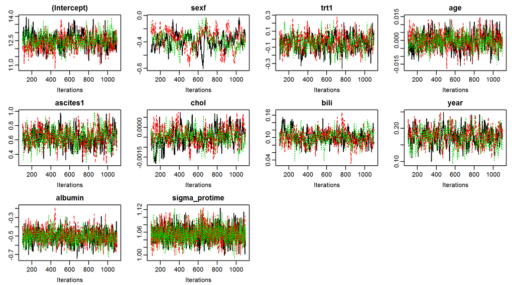

```r
traceplot(JointAIlong)
```

```r
summary(JointAIlong)
```

```
##
##  Linear mixed model fitted with JointAI
##
## Call:
## lme_imp(fixed = protime ~ year + sex + trt + age + ascites +
##     bili + chol + albumin, data = pbclong, random = ~year | id,
##     n.iter = 1000)
##
## Posterior summary:
##                   Mean        SD      2.5%      97.5% tail-prob.
## (Intercept) 12.4658318 0.4422449 11.617406 13.3464978     0.0000
## sexf        -0.3743174 0.1259117 -0.643254 -0.1322169     0.0000
## trt1        -0.0395236 0.0929152 -0.219285  0.1431631     0.6853
## age         -0.0004589 0.0047021 -0.009527  0.0085249     0.9233
## ascites1     0.6400532 0.1131918  0.417807  0.8584310     0.0000
## chol        -0.0004590 0.0004162 -0.001305  0.0003552     0.2787
## bili         0.1011336 0.0176572  0.067098  0.1372221     0.0000
## year         0.1748672 0.0254350  0.124481  0.2245679     0.0000
## albumin     -0.5028811 0.0713086 -0.642351 -0.3593372     0.0000
##
## Posterior summary of random effects covariance matrix:
##          Mean     SD   2.5%  97.5%
## D[1,1] 0.7510 0.1407 0.5068 1.0517
## D[1,2] 0.6415 0.1238 0.4327 0.9009
## D[2,2] 0.8591 0.1426 0.6095 1.1662
##
## Posterior summary of residual std. deviation:
##                Mean      SD  2.5% 97.5%
## sigma_protime 1.056 0.02058 1.016 1.098
##
##
## MCMC settings:
## Iterations = 101:1100
## Sample size per chain = 1000
## Thinning interval = 1
## Number of chains = 3
##
## Number of observations: 1945
## Number of groups: 312
```

### Imputation using **jomo**

The package **jomo** provides functionality to impute normal and non-normal longitudinal outcomes using the functions `jomo.lmer()` and `jomo.glmer()`, which use the model specification of the complete data versions `lmer()` and `glmer()` from the package **lme4**.

Different to the other `jomo.<...>()` functions is that here the level of each variable in the dataset (1 for repeated measurements, 2 for baseline covariates) needs to be specified.

Refer to the [help page](https://www.rdocumentation.org/packages/jomo/versions/2.6-2/topics/jomo.lmer) of `jomo.lmer()` or the details provided in the previous part of this practical to get more information on the other parameters that need to be specified.

**Note:**  
In the current version of **jomo** the random intercept needs to be specified explicitely, i.e. `(1 + year|id)` instead of `(year|id)`.

#### Solution 1

```r
# specify the levels of the variables
lvl_jomolong <- c(protime = 1, year = 1, sex = 2, trt = 2, age = 2, ascites = 2,
                  bili = 2, chol = 2, albumin = 1, id = 1)

t0 <- Sys.time()
jomolong <- jomo.lmer(protime ~ year + sex + trt + age + ascites +
                                      bili + chol + albumin + (1 + year|id),
                                    data = pbclong,
                                    level = lvl_jomolong, meth = "common", output = 0,
                                    nburn = 6000, nbetween = 100)
```

```
## This function is beta software. Use carefully and please report any bug to the package mantainer
```

```r
t1 <- Sys.time()
t1 - t0
```

```
## Time difference of 1.25284 mins
```

#### Continue

When we try to convert the long format dataset returned by `jomo.lmer()` to a `mids` object using `as.mids()` (like we did in the previous part of this practical), we get an error message: `Error in row.names<-.data.frame(*tmp*, value = value) : duplicate 'row.names' are not allowed`. This is because `as.mids()` wants to assign the id variable as rownames. Since we have longitudinal data, where the same id occurs more than once, this leads to an error.

Instead, we use the function `datalist2mids()` from the **miceadds** package.

#### Task 2

Analyse the imputed data and pool the results, using the following steps:

1. split `jomolong` by imputation number into a list of imputed datasets
2. exclude the first element, which contains the original data
3. convert to a `mids` object using `datalist2mids()`
4. analyse the `mids` object
5. pool the results

To split a dataset into a list, use `split()`.

**Note:**  
`jomo.lmer()` changes the `id` variable to `clus`. When analysing the imputed data, you need to use `clus` in the random effects specification.

#### Solution 2

```r
library(miceadds)
jomolong_mids <- datalist2mids(
  split(jomolong, jomolong$Imputation)[-1] # split and remove first element
)

# analyse using nlme package:
jomolong_mira <- with(jomolong_mids, lme(protime ~ year + sex + trt + age + ascites +
                                     bili + chol + albumin,
                                   random = ~ year|clus))

# alternative: lme4 package
jomolong_mira <- with(jomolong_mids, lmer(protime ~ year + sex + trt + age + ascites +
                                            bili + chol + albumin + (year|clus))
)

summary(pool(jomolong_mira))
```

```
##                       est           se           t          df
## (Intercept) 12.0352051381 0.4736593732 25.40898759   57.287049
## year         0.1828168464 0.0253910341  7.20005516 1840.437431
## sex2        -0.3382414817 0.1370880276 -2.46733057 1208.885199
## trt2        -0.0070239764 0.0896235333 -0.07837201  499.940198
## age          0.0013753408 0.0051316074  0.26801364   43.922315
## ascites2     0.6178601227 0.1094183878  5.64676683   55.768803
## bili         0.1072510482 0.0170414872  6.29352632   29.374660
## chol        -0.0001986744 0.0005016317 -0.39605636    8.334568
## albumin     -0.4553909611 0.0708202622 -6.43023546 1103.837515
##                 Pr(>|t|)        lo 95         hi 95 nmis        fmi
## (Intercept) 0.000000e+00 11.086821593 12.9835886831   NA 0.28348206
## year        8.730794e-13  0.133018584  0.2326151082    0 0.01012662
## sex2        1.375022e-02 -0.607198360 -0.0692846034   NA 0.03569858
## trt2        9.375635e-01 -0.183109161  0.1690612086   NA 0.07955791
## age         7.899435e-01 -0.008967251  0.0117179325    0 0.32682475
## ascites2    5.728259e-07  0.398648699  0.8370715467   NA 0.28761337
## bili        6.750873e-07  0.072416593  0.1420855037  539 0.40382334
## chol        7.020101e-01 -0.001347406  0.0009500573  615 0.74301874
## albumin     1.893090e-10 -0.594348489 -0.3164334330    0 0.04005998
##                  lambda
## (Intercept) 0.258896228
## year        0.009051513
## sex2        0.034104538
## trt2        0.075883048
## age         0.296854111
## ascites2    0.262515544
## bili        0.364568473
## chol        0.687958613
## albumin     0.038322277
```

### Comparison of the results for the longitudinal pbc data

We have imputed the longitudinal pbc data using three different approaches:

Here is how the pooled results from these imputations compare:

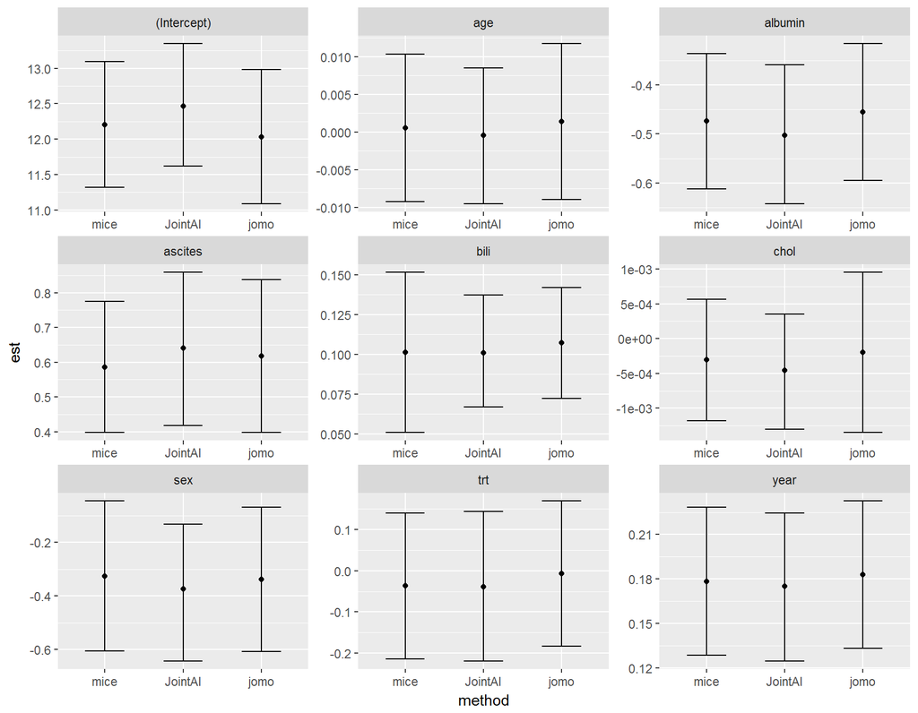

## Survival data

### Data & Model of interest

In this part of the practical, we will work with a different subset of the PBC data, omitting the longitudinal structure and focusing on the survival component.

To get the **pbcdat** data, load the file `pbcdat.RData`.

The variables contained in this subset (`pbcdat`) are:

| time | number of years between inclusion and death, transplantion, or end of follow-up |
| --- | --- |
| status | status at `time` (censored, transplant, dead) |
| age | patient’s age at intake |
| sex | patient’s sex |
| platelet | platelet count |
| chol | serum cholesterol |
| stage | histologic stage of disease |

The variables in `pbcdat` dataset have the following distributions:

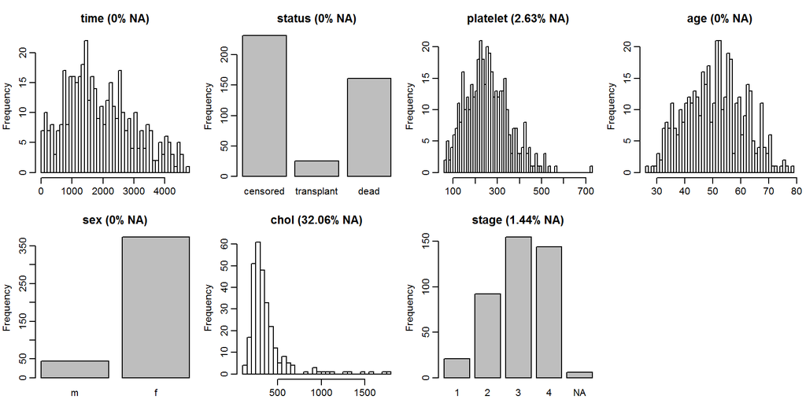

The missing data pattern is

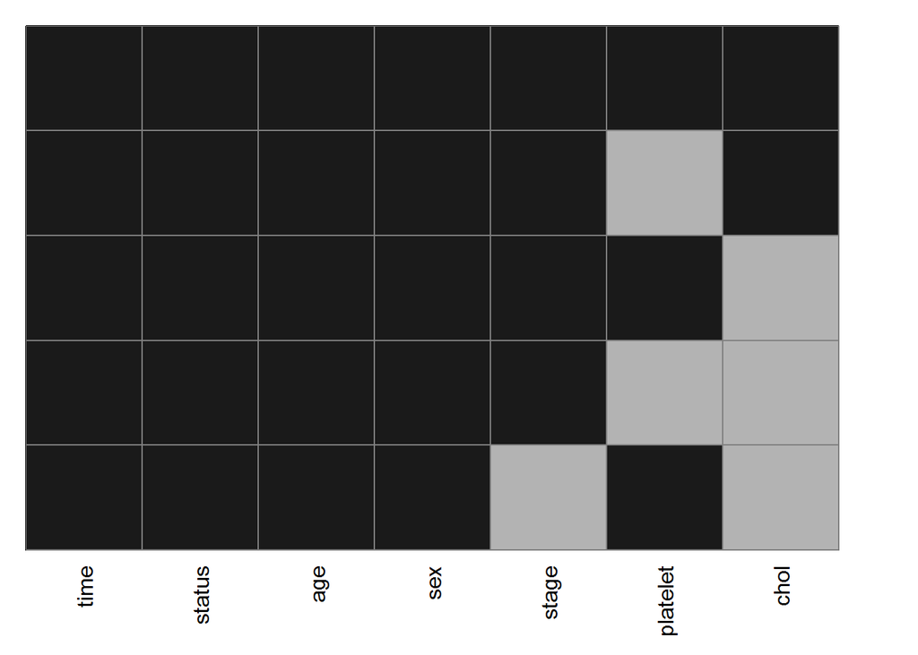

```
##     time status age sex stage platelet chol
## 280    1      1   1   1     1        1    1   0
##   4    1      1   1   1     1        0    1   1
## 121    1      1   1   1     1        1    0   1
##   7    1      1   1   1     1        0    0   2
##   6    1      1   1   1     0        1    0   2
##        0      0   0   0     6       11  134 151
```

We are interested to determine predictor variables for patient survival, using the following Cox proportional hazards model:

```r
coxph(Surv(time, status == 'dead') ~ platelet + age + sex + chol + stage)
```

### Imputation with **mice**

As we have seen in the lecture, the **mice** package provides the function `nelsonaalen()` that calculates the Nelson-Aalen estimator with which the cumulative Hazard can be approximated.

#### Task 1

Calculate the Nelson-Aalen estimate for patient survival in the pbc data and perform the usual setup steps for imputation using `mice()`. `nelsonaalen()` does not accept the `status == 'dead'` specification of the event, hence, we need to create a new event indicator `event`.

**Note:**  
`nelsonaalen()` uses the name `status` internally in such a way that it is replaced by the covariate `status` of our dataset `pbcdat`, which leads to an error. Since we do not need the column `status` for calculating the Nelson-Aalen estimate (we use `event` instead), we can exclude it from the data for just this step. To do this, use `data = subset(pbcdat, select = -c(status))` inside the `nelsonaalen()` function.

#### Solution 1

```r
pbcdat$event <- as.numeric(pbcdat$status == 'dead')

pbcdat$na <- nelsonaalen(data = subset(pbcdat, select = -c(status)),
                         timevar = "time",
                         statusvar = "event")

micesurv0 <- mice(pbcdat, maxit = 0)
micesurvmeth <- micesurv0$meth
micesurvpred <- micesurv0$pred

micesurvmeth[c("chol")] <- "midastouch"
micesurvmeth[c("platelet")] <- "norm"

micesurvpred[, "event"] <- 0

# check the method and predictorMatrix
micesurvmeth
```

```
##         time       status     platelet          age          sex
##           ""           ""       "norm"           ""           ""
##         chol        stage        event           na
## "midastouch"       "polr"           ""           ""
```

```r
micesurvpred
```

```
##          time status platelet age sex chol stage event na
## time        0      0        0   0   0    0     0     0  0
## status      0      0        0   0   0    0     0     0  0
## platelet    1      1        0   1   1    1     1     0  1
## age         0      0        0   0   0    0     0     0  0
## sex         0      0        0   0   0    0     0     0  0
## chol        1      1        1   1   1    0     1     0  1
## stage       1      1        1   1   1    1     0     0  1
## event       0      0        0   0   0    0     0     0  0
## na          0      0        0   0   0    0     0     0  0
```

#### Task 2

Now run the imputation, and analyse the imputed data.

#### Solution 2

```r
micesurv <- mice(pbcdat, predictorMatrix = micesurvpred, maxit = 10, m = 5)
micesurv_mira <- with(micesurv, coxph(Surv(time = time, event) ~ platelet +
                               age + sex + chol + stage))

summary(pool(micesurv_mira))
```

```
##                   est           se          t           df     Pr(>|t|)
## platelet -0.001676851 0.0008545894 -1.9621712 667350.73805 0.0497429764
## age       0.031933337 0.0085319292  3.7428038    559.96075 0.0002007662
## sex2     -0.131691486 0.2322575355 -0.5670063   5201.00897 0.5707343696
## chol      0.001724715 0.0003914161  4.4063479     15.44709 0.0004776080
## stage2    0.828197461 0.7406398948  1.1182188 493710.74913 0.2634740973
## stage3    1.180002850 0.7284429377  1.6198974 213714.22744 0.1052557852
## stage4    2.166069485 0.7219003810  3.0005102 983446.29700 0.0026953444
##                 lo 95         hi 95 nmis          fmi       lambda
## platelet -0.003351818 -1.883183e-06   11 0.0014130244 0.0014100318
## age       0.015174841  4.869183e-02    0 0.0877450099 0.0844925363
## sex2     -0.587013852  3.236309e-01   NA 0.0280317399 0.0276580504
## chol      0.000892530  2.556901e-03  134 0.5621100139 0.5088617039
## stage2   -0.623433617  2.279829e+00   NA 0.0020273539 0.0020233112
## stage3   -0.247727158  2.607733e+00   NA 0.0038435334 0.0038342111
## stage4    0.751168996  3.580970e+00   NA 0.0002594962 0.0002574631
```

Again, we remove the added column from the dataset to use the original data in the subsequent imputations.

```r
pbcdat <- subset(pbcdat, select = -c(na))
```

### Imputation with **smcfcs**

An alternative approach, that aims to remove the bias introduced by using the Nelson-Aalen estimator to approximate the cumulative hazard is implemented in the package **smcfcs**.

If you are uncertain which parameters need to be specified, check the [help page](https://www.rdocumentation.org/packages/smcfcs/versions/1.3.0/topics/smcfcs) for the function `smcfcs()` or go back to the first part of this practical where some of the details about the specification were described.

#### Task 1

Impute the `pbcdat` data with `smcfcs()` and the model formula specified above. We will skip the confirmation of convergence in the interest of time.

`smcfcs()` does can not handle the event specification used in the complete data model above (`status == 'dead'`), so you need to use `event` instead.

#### Solution 1

```r
# specify imputation method (in order of variables in dataset)
meth_smcsurv <- c(time = "", status = "", platelet = "norm",
                  age = "", sex = "", chol = "norm", stage = "podds",
                  event = "")

# impute the data
smcsurv <- smcfcs(originaldata = pbcdat,
                  smtype = "coxph",
                  smformula = "Surv(time = time, event) ~ platelet +
                               age + sex + chol + stage",
                  method = meth_smcsurv, numit = 20)
```

```
## [1] "Outcome variable(s): time,event"
## [1] "Passive variables: "
## [1] "Partially obs. variables: platelet,chol,stage"
## [1] "Fully obs. substantive model variables: age,sex"
## [1] "Imputation  1"
## [1] "Imputing:  platelet  using  chol,stage,age,sex  plus outcome"
## [1] "Imputing:  chol  using  platelet,stage,age,sex  plus outcome"
## [1] "Imputing:  stage  using  platelet,chol,age,sex  plus outcome"
## [1] "Imputation  2"
## [1] "Imputation  3"
## [1] "Imputation  4"
## [1] "Imputation  5"
```

#### Task 2

Assuming the algorithm has converged (it has for the settings chosen in the solution), fit the Cox model and pool the results.

#### Solution 2

```r
# create mids object or imputationList object
smcsurv_impList <- mitools::imputationList(smcsurv$impDatasets)

opt <- getOption("contrasts")
# this specifies that ordinal factors are treated as unordered factors when covariate in a model
options(contrasts = rep("contr.treatment", 2))

smcsurv_models <- with(smcsurv_impList, coxph(Surv(time = time, event) ~ platelet +
                               age + sex + chol + stage))
# re-set the option for factors
options(contrasts = opt)

smcsurv_mira <- as.mira(smcsurv_models)

summary(pool(smcsurv_mira))
```

```
##                   est           se          t         df     Pr(>|t|)
## platelet -0.001664645 0.0008852968 -1.8803239 1781.21750 6.022700e-02
## age       0.031418288 0.0082190217  3.8226311 5097.05589 1.336096e-04
## sexf     -0.131084204 0.2373024994 -0.5523928  723.04413 5.808499e-01
## chol      0.001655668 0.0003265741  5.0698073   78.26431 2.604791e-06
## stage2    0.740917719 0.7488679758  0.9893836  592.91010 3.228791e-01
## stage3    1.087659544 0.7506405645  1.4489752  274.83498 1.484845e-01
## stage4    2.074017851 0.7467009622  2.7775749  257.79361 5.878938e-03
##                 lo 95        hi 95 nmis        fmi     lambda
## platelet -0.003400975 7.168496e-05   NA 0.04841189 0.04734402
## age       0.015305475 4.753110e-02   NA 0.02832134 0.02794015
## sexf     -0.596968416 3.348000e-01   NA 0.07689932 0.07434948
## chol      0.001005543 2.305793e-03   NA 0.24510871 0.22606127
## stage2   -0.729838833 2.211674e+00   NA 0.08519048 0.08210985
## stage3   -0.390076314 2.565395e+00   NA 0.12695211 0.12062189
## stage4    0.603607733 3.544428e+00   NA 0.13125982 0.12454605
```

### Imputation with **jomo**

To impute the pbc survival data with the package **jomo** we use the function `jomo.coxph()`, which works analogously to the other `jomo.<...>()` functions we have seen.

#### Task

Perform the imputation, analyse the imputed data and pool the results. Again, we will skip the convergence check to save some time. Use `nburn = 1000` and `nbetween = 500`. As in the previous imputation approaches, we use the new event indicator `event` instead of `status == 'dead'`. Since **jomo** considers all extra columns as auxiliary variables, we need to exclude `status` to prevent multicollinearity issues.

To exclude the variable `status` use `data = subset(pbcdat, select = -status)`.

To run the analysis on the imputed data, convert the long format data to a `mids` object, like we did in the NHANES example.

#### Solution

```r
jomosurv <- jomo.coxph(formula = Surv(time = time, event) ~ platelet +
                         age + sex + chol + stage,
                       data = subset(pbcdat, select = -status),
                       nburn = 1000, nbetween = 500, nimp = 5)
```

```
## This function is beta software. Use carefully and please report any bug to the package mantainer
## ....................................................................................................First imputation registered.
## ..................................................Imputation number  2 registered
## ..................................................Imputation number  3 registered
## ..................................................Imputation number  4 registered
## ..................................................Imputation number  5 registered
## The posterior mean of the substantive model fixed effects estimates is:
##              [,1]       [,2]       [,3]        [,4]      [,5]     [,6]
## [1,] -0.001689413 0.03033028 -0.1590813 0.001624706 0.8290559 1.185823
##          [,7]
## [1,] 2.177435
## The posterior mean of the fixed effects estimates is:
##          [,1]     [,2]    [,3]      [,4]       [,5]       [,6]       [,7]
## [1,] 257.3608 50.75125 361.899 -1.243897 -0.8695723 -0.2447639 0.03887031
## The posterior mean of the level 1 covariance matrix is:
##             [,1]        [,2]         [,3]          [,4]        [,5]
## [1,] 10081.17671 -158.519441  4668.549894 -14.864777204  28.8148078
## [2,]  -158.51944  113.872880  -409.899117   2.697448872  -2.8129306
## [3,]  4668.54989 -409.899117 56610.680096  -2.721809446 -33.4697236
## [4,]   -14.86478    2.697449    -2.721809   1.000000000   0.1193999
## [5,]    28.81481   -2.812931   -33.469724   0.119399884   1.0000000
## [6,]    31.43644   -2.280797    17.576072  -0.029579399   0.5000000
## [7,]    21.67179   -2.714652    45.083911  -0.008085163   0.5000000
##            [,6]         [,7]
## [1,] 31.4364425 21.671793777
## [2,] -2.2807973 -2.714652419
## [3,] 17.5760715 45.083911312
## [4,] -0.0295794 -0.008085163
## [5,]  0.5000000  0.500000000
## [6,]  1.0000000  0.500000000
## [7,]  0.5000000  1.000000000
```

```r
jomosurv_mids <- as.mids(jomosurv,
                         .id = which(names(jomosurv) == "id"),
                         .imp = which(names(jomosurv) == "Imputation"))


jomosurv_mira <- with(jomosurv_mids, coxph(Surv(time, event) ~ platelet +
                                             age + sex + chol + stage))


summary(pool(jomosurv_mira))
```

```
##                   est           se          t          df     Pr(>|t|)
## platelet -0.001691366 0.0008870868 -1.9066520    969.6869 5.686100e-02
## age       0.030207616 0.0082724220  3.6516049   3700.0630 2.642126e-04
## sex2     -0.157529403 0.2320676121 -0.6788082   3363.3129 4.973061e-01
## chol      0.001685627 0.0002923402  5.7659777  12278.4169 8.314123e-09
## stage2    0.813236202 0.7461368535  1.0899290  16795.5125 2.757601e-01
## stage3    1.171263934 0.7308443974  1.6026174  40070.5028 1.090270e-01
## stage4    2.186169910 0.7238903392  3.0200291 134033.4524 2.527980e-03
##                 lo 95        hi 95 nmis         fmi      lambda
## platelet -0.003432197 4.946521e-05   11 0.066117381 0.064193212
## age       0.013988662 4.642657e-02    0 0.033338934 0.032816565
## sex2     -0.612537309 2.974785e-01   NA 0.034999835 0.034426166
## chol      0.001112594 2.258660e-03  134 0.018095975 0.017936048
## stage2   -0.649270553 2.275743e+00   NA 0.015417455 0.015300219
## stage3   -0.261208032 2.603736e+00   NA 0.009836376 0.009786956
## stage4    0.767358104 3.604982e+00   NA 0.005096465 0.005081619
```

### Comparison of the results for the pbc survival data

We have imputed the pbc survival data using three different approaches:

- with **mice**, using the Nelson-Aalen approximation
- with **smcfcs**
- with **jomo**

Here is how the pooled results from these imputations compare:

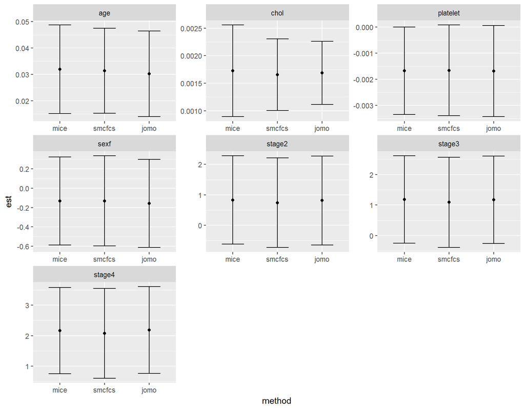

**You have reached the end of this practical. Well done!**